# Time Series and Panel Data Model

```r
Box.test(injury.ARIMA.forecast2$residuals,lag=20,type="Ljung-Box")
```

```
##
##  Box-Ljung test
##
## data:  injury.ARIMA.forecast2$residuals
## X-squared = 92.994, df = 20, p-value = 2.211e-11
```

```r
accuracy(injury.HW.forecast)
```

```
##                    ME     RMSE      MAE       MPE     MAPE      MASE       ACF1
## Training set 26.81404 566.6795 451.7194 0.1393496 2.530786 0.5274529 -0.0920753
```

```r
accuracy(injury.ARIMA.forecast)
```

```
##                    ME     RMSE      MAE        MPE   MAPE      MASE
## Training set 48.95033 1026.029 788.7051 -0.0677188 4.5122 0.9209362
##                      ACF1
## Training set -0.003080778
```

```r
accuracy(injury.ARIMA.forecast2)
```

```
##                    ME     RMSE      MAE       MPE     MAPE      MASE
## Training set 62.30627 1037.041 780.2022 0.1124229 4.454093 0.9110078
##                     ACF1
## Training set -0.01713634
```

As seen, the HoltWinters does better in forecasting than two ARIMA, so we can use HoltWinters to forecast Injury Accidents for the first three months of the year 1990

```r
injury.HW.forecast
```

```
##          Point Forecast    Lo 80    Hi 80    Lo 95    Hi 95
## Jan 1990       17778.82 17049.60 18508.05 16663.57 18894.07
## Feb 1990       17566.90 16780.04 18353.75 16363.51 18770.29
## Mar 1990       20083.37 19235.34 20931.41 18786.42 21380.33
```

2. Do you think any of the other time series covariates provided (the unemployment rates, 65 mph max speed restrictions and compulsory seatbelt use) can significantly explain any of the three distinct categories of accidents above? If so, use appropriate regression methods to identify and quantify these effects.

```r
Dtotal<- diff(total)
Dfatal<- diff(fatal)
Dinjury<- diff(injury)

rate<-ts(accidents$UnEmploymentRate,start=c(1981,1),frequency=12)
Drate<-diff(rate)

speed<-ts(accidents$SpeedLaw,start=c(1981,1),frequency=12)
Dspeed<-diff(speed)

belt<-ts(accidents$BeltLaw,start=c(1981,1),frequency=12)
Dbelt<-diff(belt)

accidents.ts<-ts.union(total,Dtotal,fatal,Dfatal,injury,Dinjury,rate,Drate,speed,Dspeed,belt,Dbelt,dframe=T)

head(accidents.ts)
```

```
##   total Dtotal fatal Dfatal injury Dinjury rate Drate speed Dspeed belt Dbelt
## 1 40511     NA   365     NA  15626      NA  7.9    NA     0     NA    0    NA
## 2 36034  -4477   329    -36  14469   -1157  8.0   0.1     0      0    0     0
## 3 40328   4294   369     40  16026    1557  7.4  -0.6     0      0    0     0
## 4 37699  -2629   369      0  15560    -466  7.2  -0.2     0      0    0     0
## 5 38816   1117   355    -14  16546     986  6.1  -1.1     0      0    0     0
## 6 38900     84   422     67  16778     232  6.7   0.6     0      0    0     0
```

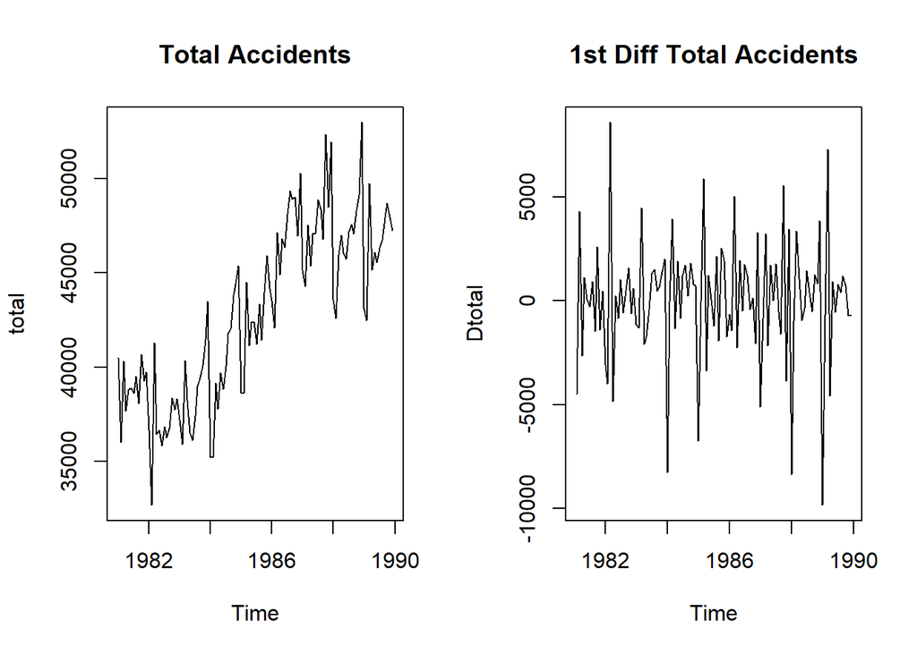

```r
par(mfrow=c(1,2))
plot(total,main="Total Accidents")
plot(Dtotal,main="1st Diff Total Accidents")
```

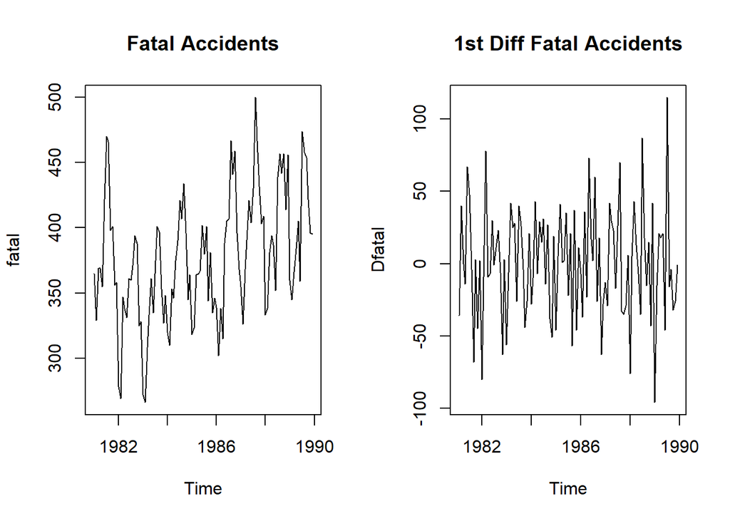

```r
par(mfrow=c(1,2))
plot(fatal,main="Fatal Accidents")
plot(Dfatal,main="1st Diff Fatal Accidents")
```

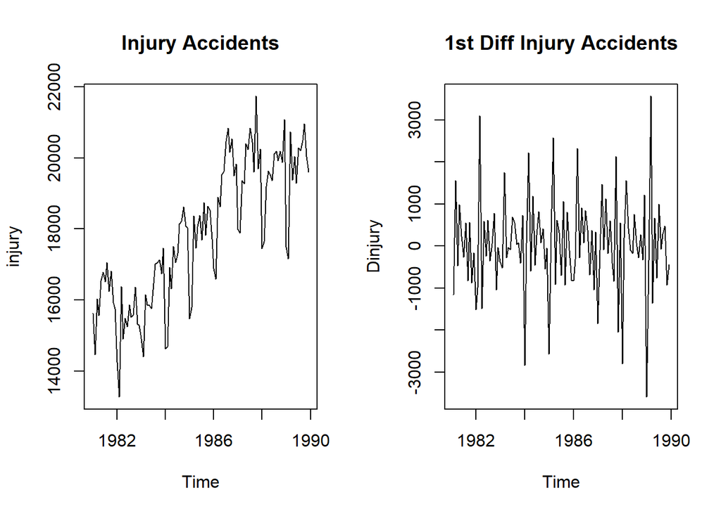

```r
par(mfrow=c(1,2))
plot(injury,main="Injury Accidents")
plot(Dinjury,main="1st Diff Injury Accidents")
```

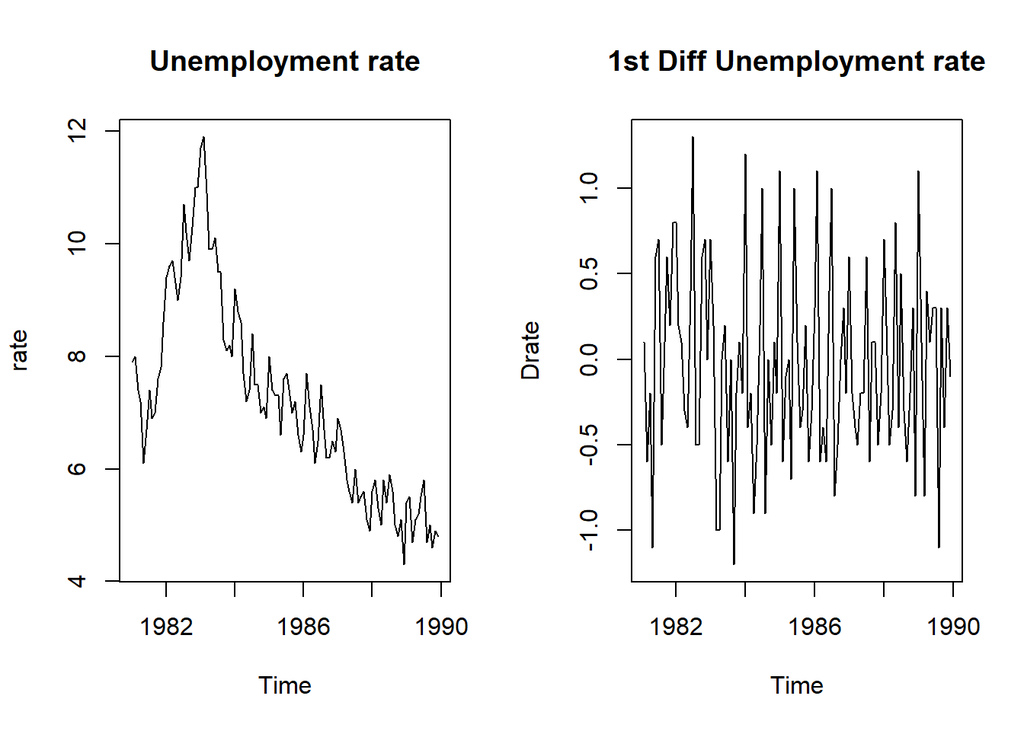

```r
par(mfrow=c(1,2))
plot(rate,main="Unemployment rate")
plot(Drate,main="1st Diff Unemployment rate")
```

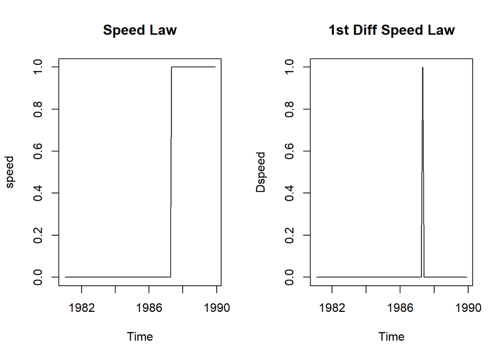

```r
par(mfrow=c(1,2))
plot(speed,main="Speed Law")
plot(Dspeed,main="1st Diff Speed Law")
```

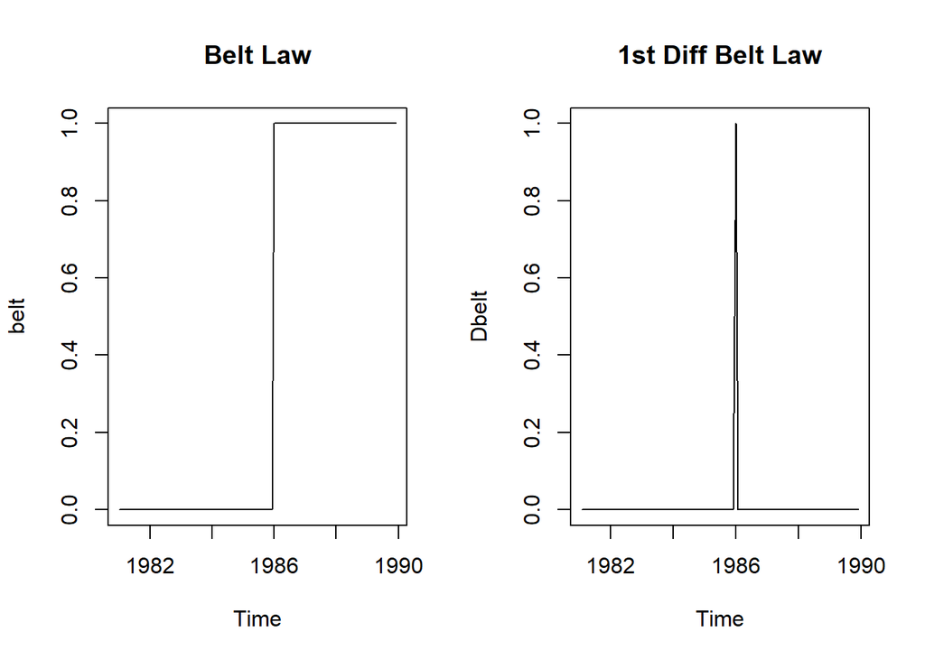

```r
par(mfrow=c(1,2))
plot(belt,main="Belt Law")
plot(Dbelt,main="1st Diff Belt Law")
```

Checking for stationary

```r
adf.test(total)
```

```
##
##  Augmented Dickey-Fuller Test
##
## data:  total
## Dickey-Fuller = -2.7048, Lag order = 4, p-value = 0.2843
## alternative hypothesis: stationary
```

```r
adf.test(Dtotal)
```

```
##
##  Augmented Dickey-Fuller Test
##
## data:  Dtotal
## Dickey-Fuller = -5.7421, Lag order = 4, p-value = 0.01
## alternative hypothesis: stationary
```

```r
adf.test(fatal)
```

```
##
##  Augmented Dickey-Fuller Test
##
## data:  fatal
## Dickey-Fuller = -5.9694, Lag order = 4, p-value = 0.01
## alternative hypothesis: stationary
```

```r
adf.test(Dfatal)
```

```
##
##  Augmented Dickey-Fuller Test
##
## data:  Dfatal
## Dickey-Fuller = -5.0798, Lag order = 4, p-value = 0.01
## alternative hypothesis: stationary
```

```r
adf.test(injury)
```

```
##
##  Augmented Dickey-Fuller Test
##
## data:  injury
## Dickey-Fuller = -3.702, Lag order = 4, p-value = 0.02734
## alternative hypothesis: stationary
```

```r
adf.test(Dinjury)
```

```
##
##  Augmented Dickey-Fuller Test
##
## data:  Dinjury
## Dickey-Fuller = -5.3133, Lag order = 4, p-value = 0.01
## alternative hypothesis: stationary
```

```r
adf.test(rate)
```

```
##
##  Augmented Dickey-Fuller Test
##
## data:  rate
## Dickey-Fuller = -3.2, Lag order = 4, p-value = 0.0915
## alternative hypothesis: stationary
```

```r
adf.test(Drate)
```

```
##
##  Augmented Dickey-Fuller Test
##
## data:  Drate
## Dickey-Fuller = -5.6797, Lag order = 4, p-value = 0.01
## alternative hypothesis: stationary
```

```r
adf.test(speed)
```

```
##
##  Augmented Dickey-Fuller Test
##
## data:  speed
## Dickey-Fuller = -1.9457, Lag order = 4, p-value = 0.5992
## alternative hypothesis: stationary
```

```r
adf.test(Dspeed)
```

```
##
##  Augmented Dickey-Fuller Test
##
## data:  Dspeed
## Dickey-Fuller = -4.5563, Lag order = 4, p-value = 0.01
## alternative hypothesis: stationary
```

```r
adf.test(belt)
```

```
##
##  Augmented Dickey-Fuller Test
##
## data:  belt
## Dickey-Fuller = -2.0917, Lag order = 4, p-value = 0.5386
## alternative hypothesis: stationary
```

```r
adf.test(Dbelt)
```

```
##
##  Augmented Dickey-Fuller Test
##
## data:  Dbelt
## Dickey-Fuller = -4.4941, Lag order = 4, p-value = 0.01
## alternative hypothesis: stationary
```

=> Given default level of significant is 5 percent for ADF test, we can see Fatal Accidents and Injury Accidents are stationary itself, others are stationary in first differences.

#### Run regression

```r
total.model<-dynlm(Dtotal~Drate+Dspeed+Dbelt-1,data=accidents.ts)
summary(total.model)
```

```
##
## Time series regression with "ts" data:
## Start = 1981(2), End = 1989(12)
##
## Call:
## dynlm(formula = Dtotal ~ Drate + Dspeed + Dbelt - 1, data = accidents.ts)
##
## Residuals:
##    Min     1Q Median     3Q    Max
##  -7767  -1384      0   1466   8771
##
## Coefficients:
##        Estimate Std. Error t value Pr(>|t|)
## Drate   -1874.3      463.9  -4.040 0.000102 ***
## Dspeed   1333.1     2710.5   0.492 0.623873
## Dbelt     -80.7     2712.5  -0.030 0.976324
## ---
## Signif. codes:  0 '***' 0.001 '**' 0.01 '*' 0.05 '.' 0.1 ' ' 1
##
## Residual standard error: 2709 on 104 degrees of freedom
##   (1 observation deleted due to missingness)
## Multiple R-squared:  0.1389, Adjusted R-squared:  0.1141
## F-statistic: 5.593 on 3 and 104 DF,  p-value: 0.001351
```

=> We can see Unemployment Rate is significant to explain Total Accidents.

```r
fatal.model<-dynlm(fatal~Drate+Dspeed+Dbelt,data=accidents.ts)
summary(fatal.model)
```

```
##
## Time series regression with "ts" data:
## Start = 1981(2), End = 1989(12)
##
## Call:
## dynlm(formula = fatal ~ Drate + Dspeed + Dbelt, data = accidents.ts)
##
## Residuals:
##      Min       1Q   Median       3Q      Max
## -109.417  -35.077   -5.258   28.761  115.552
##
## Coefficients:
##             Estimate Std. Error t value Pr(>|t|)
## (Intercept)  377.675      4.760  79.349   <2e-16 ***
## Drate        -11.289      8.352  -1.352    0.179
## Dspeed        41.067     48.954   0.839    0.403
## Dbelt        -35.288     49.011  -0.720    0.473
## ---
## Signif. codes:  0 '***' 0.001 '**' 0.01 '*' 0.05 '.' 0.1 ' ' 1
##
## Residual standard error: 48.7 on 103 degrees of freedom
##   (1 observation deleted due to missingness)
## Multiple R-squared:  0.03057,    Adjusted R-squared:  0.002329
## F-statistic: 1.082 on 3 and 103 DF,  p-value: 0.36
```

=> There is no really significant variables to explain Fatal Accidents, but seems Unemployment Rate is the best explanatory variable among others.

```r
injury.model<-dynlm(injury~Drate+Dspeed+Dbelt,data=accidents.ts)
summary(injury.model)
```

```
##
## Time series regression with "ts" data:
## Start = 1981(2), End = 1989(12)
##
## Call:
## dynlm(formula = injury ~ Drate + Dspeed + Dbelt, data = accidents.ts)
##
## Residuals:
##    Min     1Q Median     3Q    Max
##  -4450  -1566      0   1690   3958
##
## Coefficients:
##             Estimate Std. Error t value Pr(>|t|)
## (Intercept)  17848.0      189.1  94.380   <2e-16 ***
## Drate         -648.2      331.8  -1.953   0.0535 .
## Dspeed        2428.4     1945.0   1.249   0.2147
## Dbelt         -758.5     1947.3  -0.390   0.6977
## ---
## Signif. codes:  0 '***' 0.001 '**' 0.01 '*' 0.05 '.' 0.1 ' ' 1
##
## Residual standard error: 1935 on 103 degrees of freedom
##   (1 observation deleted due to missingness)
## Multiple R-squared:  0.05316,    Adjusted R-squared:  0.02558
## F-statistic: 1.927 on 3 and 103 DF,  p-value: 0.1298
```

=> Unemployment rate is also the best variable to explain Injury Accidents.

# Problem 5

```r
minwage<-read_excel("MINWAGE.xlsx")
```

1. Confirm that lwage232t and lemp232t are I(1) processes. Are you sure that these processes are stationary after 1st differencing?

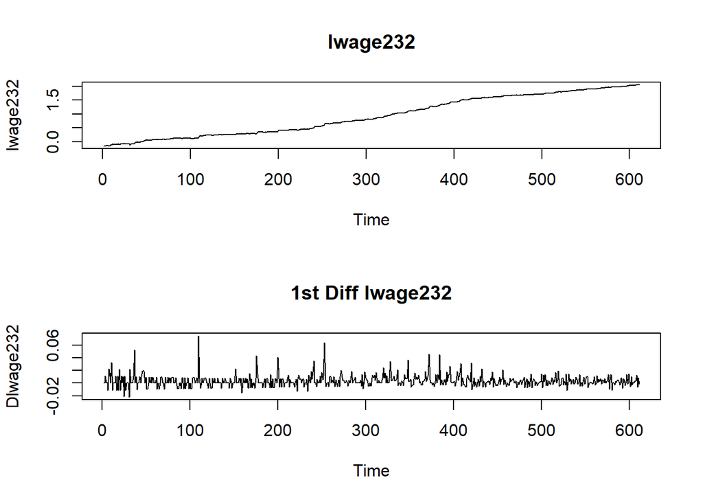

```r
lwage232<-ts(minwage$lwage232)
Dlwage232<- diff(lwage232)

par(mfrow=c(2,1))
plot(lwage232,main="lwage232")
plot(Dlwage232,main="1st Diff lwage232")
```

```r
adf.test(lwage232)
```

```
##
##  Augmented Dickey-Fuller Test
##
## data:  lwage232
## Dickey-Fuller = -1.2896, Lag order = 8, p-value = 0.879
## alternative hypothesis: stationary
```

```r
adf.test(Dlwage232)
```

```
##
##  Augmented Dickey-Fuller Test
##
## data:  Dlwage232
## Dickey-Fuller = -9.0475, Lag order = 8, p-value = 0.01
## alternative hypothesis: stationary
```

=> p-value of Dlwage232 in ADF test is 0.01, we can confirm that lwage232 is stationary in first difference.

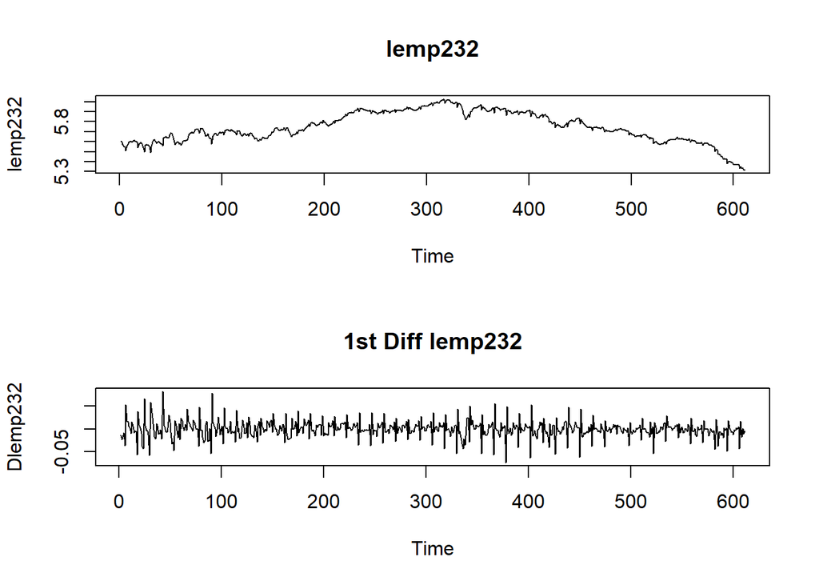

```r
lemp232<-ts(minwage$lemp232)
Dlemp232<- diff(lemp232)

par(mfrow=c(2,1))
plot(lemp232,main="lemp232")
plot(Dlemp232,main="1st Diff lemp232")
```

```r
adf.test(lemp232)
```

```
##
##  Augmented Dickey-Fuller Test
##
## data:  lemp232
## Dickey-Fuller = -0.011407, Lag order = 8, p-value = 0.99
## alternative hypothesis: stationary
```

```r
adf.test(Dlemp232)
```

```
##
##  Augmented Dickey-Fuller Test
##
## data:  Dlemp232
## Dickey-Fuller = -9.4186, Lag order = 8, p-value = 0.01
## alternative hypothesis: stationary
```

=> p-value of Dlemp232 in ADF test is 0.01, we can confirm that lemp232 is stationary in first difference.

2. Regress lemp232t on lwage232t both with and without a time trend. Are they cointegrated? What do you conclude?

#### Without time trend

```r
reg1<-dynlm(Dlemp232~Dlwage232-1)
summary(reg1)
```

```
##
## Time series regression with "ts" data:
## Start = 2, End = 611
##
## Call:
## dynlm(formula = Dlemp232 ~ Dlwage232 - 1)
##
## Residuals:
##       Min        1Q    Median        3Q       Max
## -0.073472 -0.008207  0.000101  0.008512  0.082518
##
## Coefficients:
##           Estimate Std. Error t value Pr(>|t|)
## Dlwage232 -0.05662    0.07502  -0.755    0.451
##
## Residual standard error: 0.01865 on 609 degrees of freedom
## Multiple R-squared:  0.0009346,  Adjusted R-squared:  -0.000706
## F-statistic: 0.5697 on 1 and 609 DF,  p-value: 0.4507
```

```r
reg1.bfx<-as.matrix(cbind(lemp232,lwage232),demean=F)
po.test(reg1.bfx)
```

```
##
##  Phillips-Ouliaris Cointegration Test
##
## data:  reg1.bfx
## Phillips-Ouliaris demeaned = -0.34807, Truncation lag parameter = 6,
## p-value = 0.15
```

#### With time trend

```r
t <- ts(minwage$t)

reg2<-dynlm(Dlemp232~Dlwage232+t)
summary(reg2)
```

```
##
## Time series regression with "ts" data:
## Start = 2, End = 611
##
## Call:
## dynlm(formula = Dlemp232 ~ Dlwage232 + t)
##
## Residuals:
##       Min        1Q    Median        3Q       Max
## -0.072421 -0.007736  0.000549  0.008418  0.080306
##
## Coefficients:
##               Estimate Std. Error t value Pr(>|t|)
## (Intercept)  2.477e-03  1.541e-03   1.608   0.1084
## Dlwage232   -4.324e-02  8.024e-02  -0.539   0.5902
## t           -9.109e-06  4.278e-06  -2.129   0.0336 *
## ---
## Signif. codes:  0 '***' 0.001 '**' 0.01 '*' 0.05 '.' 0.1 ' ' 1
##
## Residual standard error: 0.0186 on 607 degrees of freedom
## Multiple R-squared:  0.007931,   Adjusted R-squared:  0.004662
## F-statistic: 2.426 on 2 and 607 DF,  p-value: 0.08923
```

```r
reg2.bfx<-as.matrix(cbind(lemp232,lwage232,t),demean=F)
po.test(reg2.bfx)
```

```
##
##  Phillips-Ouliaris Cointegration Test
##
## data:  reg2.bfx
## Phillips-Ouliaris demeaned = 0.5858, Truncation lag parameter = 6,
## p-value = 0.15
```

The p-value in both case ( with and without time trend) are 0.15, do not reject H0:Non-cointigration as 5% level, which means they are not cointergrated.

3. Now regress lemp232t on log of the real wage rate (lrwage232t = lwage232t – lcpit) and a time trend. Do you find cointegration? Are they “closer” to being cointegrated when you use real wages than the actual wages lwage232t ?

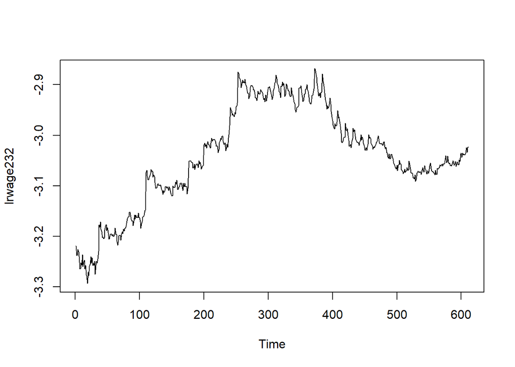

```r
lrwage232<-ts(minwage$lwage232-minwage$lcpi)
plot.ts(lrwage232)
```

```r
adf.test(lrwage232)
```

```
##
##  Augmented Dickey-Fuller Test
##
## data:  lrwage232
## Dickey-Fuller = -1.3206, Lag order = 8, p-value = 0.8659
## alternative hypothesis: stationary
```

=> The lrwage232 is not stationary. So we need to difference it.

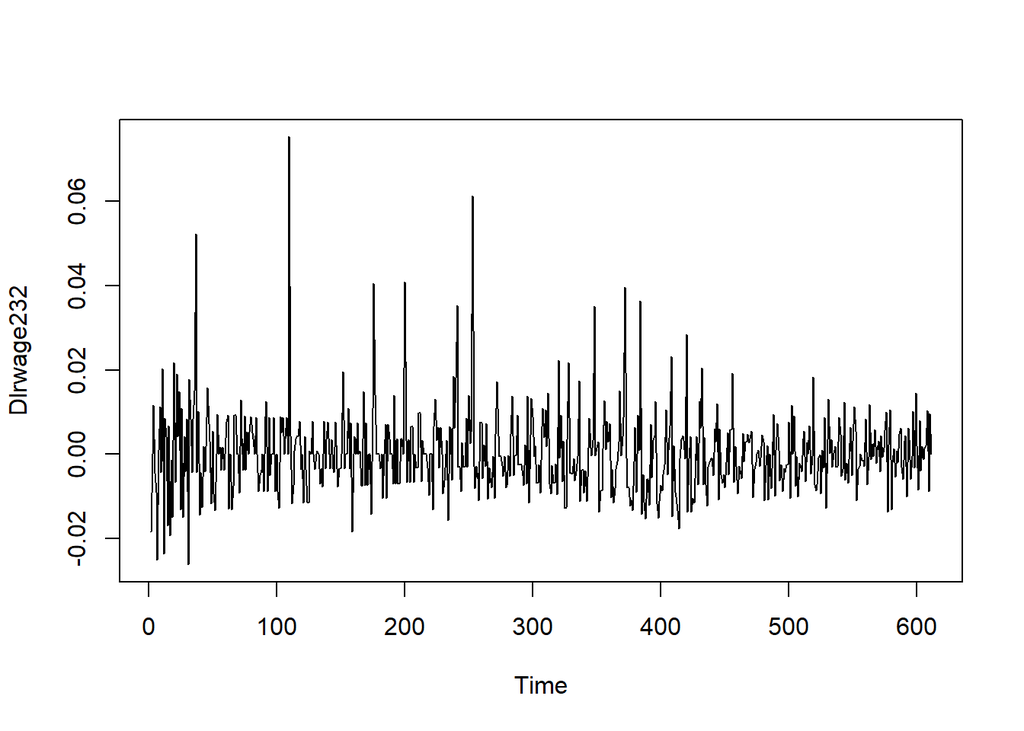

```r
Dlrwage232<-diff(lrwage232)
plot.ts(Dlrwage232)
```

```r
adf.test(Dlrwage232)
```

```
##
##  Augmented Dickey-Fuller Test
##
## data:  Dlrwage232
## Dickey-Fuller = -10.992, Lag order = 8, p-value = 0.01
## alternative hypothesis: stationary
```

=> We can see the lrwage232 is stationary in first difference.

Now check whether they are cointergrated.

```r
bfx<-as.matrix(cbind(lemp232,lrwage232,t),demean=F)
po.test(bfx)
```

```
##
##  Phillips-Ouliaris Cointegration Test
##
## data:  bfx
## Phillips-Ouliaris demeaned = -24.606, Truncation lag parameter = 6,
## p-value = 0.06671
```

The p-value is 0.06671, they are much closer to be cointergrated than using actual wage.

Now run regression

```r
reg3<-dynlm(Dlemp232~Dlrwage232+t)
summary(reg3)
```

```
##
## Time series regression with "ts" data:
## Start = 2, End = 611
##
## Call:
## dynlm(formula = Dlemp232 ~ Dlrwage232 + t)
##
## Residuals:
##       Min        1Q    Median        3Q       Max
## -0.072673 -0.007618  0.000559  0.008349  0.080060
##
## Coefficients:
##               Estimate Std. Error t value Pr(>|t|)
## (Intercept)  2.383e-03  1.518e-03   1.570   0.1170
## Dlrwage232  -4.875e-02  7.692e-02  -0.634   0.5264
## t           -9.262e-06  4.282e-06  -2.163   0.0309 *
## ---
## Signif. codes:  0 '***' 0.001 '**' 0.01 '*' 0.05 '.' 0.1 ' ' 1
##
## Residual standard error: 0.0186 on 607 degrees of freedom
## Multiple R-squared:  0.008112,   Adjusted R-squared:  0.004844
## F-statistic: 2.482 on 2 and 607 DF,  p-value: 0.0844
```

# Problem 6

```r
airfarepanel<-read_excel("AirfarePanel.xls")
airpanel <-pdata.frame(airfarepanel,index=c("id", "year"))
pdim(airpanel)
```

```
## Balanced Panel: n = 1149, T = 4, N = 4596
```

```r
mod1.pooled<-plm(lfare~concen+ldist+ldistsq+y98+y99+y00,model="pooling",data=airpanel)
summary(mod1.pooled)
```

```
## Pooling Model
##
## Call:
## plm(formula = lfare ~ concen + ldist + ldistsq + y98 + y99 +
##     y00, data = airpanel, model = "pooling")
##
## Balanced Panel: n = 1149, T = 4, N = 4596
##
## Residuals:
##      Min.   1st Qu.    Median   3rd Qu.      Max.
## -1.307954 -0.253739 -0.026729  0.247446  0.958113
##
## Coefficients:
##               Estimate Std. Error t-value  Pr(>|t|)
## (Intercept)  6.2092416  0.4206246 14.7620 < 2.2e-16 ***
## concen       0.3601202  0.0300691 11.9764 < 2.2e-16 ***
## ldist       -0.9015955  0.1282730 -7.0287 2.391e-12 ***
## ldistsq      0.1030192  0.0097255 10.5927 < 2.2e-16 ***
## y98          0.0211244  0.0140419  1.5044  0.132553
## y99          0.0378496  0.0140413  2.6956  0.007052 **
## y00          0.0998700  0.0140432  7.1116 1.324e-12 ***
## ---
## Signif. codes:  0 '***' 0.001 '**' 0.01 '*' 0.05 '.' 0.1 ' ' 1
##
## Total Sum of Squares:    875.09
## Residual Sum of Squares: 519.64
## R-Squared:      0.40619
## Adj. R-Squared: 0.40541
## F-statistic: 523.175 on 6 and 4589 DF, p-value: < 2.22e-16
```

```r
concen<-coef(mod1.pooled)[2]
concen
```

```
##    concen
## 0.3601202
```

When concen increase 0.1, the air fare will increase 3.601%.

Use robert standard errors

```r
mod1.pooled.RSE <- tidy(coeftest(mod1.pooled, vcov=vcovHC(mod1.pooled,type="HC0", cluster="group")))
kable(mod1.pooled.RSE, digits=3, caption= "Pooled Air Panel model with robust standard errors")
```

Pooled Air Panel model with robust standard errors

| term | estimate | std.error | statistic | p.value |
| --- | --- | --- | --- | --- |
| (Intercept) | 6.209 | 0.911 | 6.818 | 0.000 |
| concen | 0.360 | 0.058 | 6.157 | 0.000 |
| ldist | -0.902 | 0.272 | -3.319 | 0.001 |
| ldistsq | 0.103 | 0.020 | 5.116 | 0.000 |
| y98 | 0.021 | 0.004 | 5.099 | 0.000 |
| y99 | 0.038 | 0.005 | 7.316 | 0.000 |
| y00 | 0.100 | 0.006 | 17.705 | 0.000 |

```r
lowlimit<-mod1.pooled.RSE[2,2]-1.96*mod1.pooled.RSE[2,3]
uplimit <- mod1.pooled.RSE[2,2]+1.96*mod1.pooled.RSE[2,3]
paste('The confidence interval at 95% level of confidence is:',lowlimit,'and', uplimit)
```

```
## [1] "The confidence interval at 95% level of confidence is: 0.245475249485531 and 0.474765205908021"
```

2. What does the estimate quadratic in log(distance) tell you about the effects of the distance of the route on the fares charged?

The coefficient of ldistsq is 0.10302, which means that when log of distance square increases 1%, fare will increase 0.103%

3. Now estimate the random effects model. How does the estimate of β1 change?

```r
compare_r_p <- plmtest(mod1.pooled, effect="individual")
kable(tidy(compare_r_p ))
```

| statistic | p.value | method | alternative |
| --- | --- | --- | --- |
| 74.60635 | 0 | Lagrange Multiplier Test - (Honda) for balanced panels | significant effects |

There are Heterogeneity among individuals.

```r
mod1.random <- plm(lfare~concen+ldist+ldistsq+y98+y99+y00,model="random",random.method="swar",data=airpanel)
kable(tidy(mod1.random), digits=4)
```

| term | estimate | std.error | statistic | p.value |
| --- | --- | --- | --- | --- |
| (Intercept) | 6.2220 | 0.8100 | 7.6818 | 0e+00 |
| concen | 0.2090 | 0.0265 | 7.8777 | 0e+00 |
| ldist | -0.8521 | 0.2465 | -3.4570 | 5e-04 |
| ldistsq | 0.0975 | 0.0186 | 5.2297 | 0e+00 |
| y98 | 0.0225 | 0.0045 | 5.0454 | 0e+00 |
| y99 | 0.0367 | 0.0045 | 8.2398 | 0e+00 |
| y00 | 0.0982 | 0.0045 | 22.0324 | 0e+00 |

4. Now estimate the fixed effects model (i.e. now we use the plm function with model = “within” to include the a’s) How does this compare with the pooled model and the RE models? Are you satisfied that the concentration on a route has a significant effect on the fares of that route?

```r
mod1.within <- plm(lfare~concen+ldist+ldistsq,data=airpanel,model="within")
kable(tidy(mod1.within), digits=4)
```

| term | estimate | std.error | statistic | p.value |
| --- | --- | --- | --- | --- |
| concen | 0.1031 | 0.0312 | 3.2985 | 0.001 |

```r
kable(tidy(phtest(mod1.within, mod1.random)), caption= "Hausman endogeneity test for the random effects wage model")
```

Hausman endogeneity test for the random effects wage model

| statistic | p.value | parameter | method | alternative |
| --- | --- | --- | --- | --- |
| 41.22601 | 0 | 1 | Hausman Test | one model is inconsistent |

Null hypothesis is random effects are exogenous is rejected. This makes the random effects equation inconsistent.

```r
kable(tidy(pFtest(mod1.within, mod1.pooled)), digits=2,caption="Fixed effects test: Ho:'No fixed effects'")
```

```
## Multiple parameters; naming those columns df1, df2
```

Fixed effects test: Ho:‘No fixed effects’

| df1 | df2 | statistic | p.value | method | alternative |
| --- | --- | --- | --- | --- | --- |
| 1143 | 3446 | 31.78 | 0 | F test for individual effects | significant effects |

Null hypothesis is no fixed effects is rejected - thus the FE model is better.

```r
summary(mod1.within)
```

```
## Oneway (individual) effect Within Model
##
## Call:
## plm(formula = lfare ~ concen + ldist + ldistsq, data = airpanel,
##     model = "within")
##
## Balanced Panel: n = 1149, T = 4, N = 4596
##
## Residuals:
##        Min.     1st Qu.      Median     3rd Qu.        Max.
## -0.92015599 -0.05116991  0.00019641  0.05335239  0.97909706
##
## Coefficients:
##        Estimate Std. Error t-value Pr(>|t|)
## concen 0.103051   0.031242  3.2985 0.000982 ***
## ---
## Signif. codes:  0 '***' 0.001 '**' 0.01 '*' 0.05 '.' 0.1 ' ' 1
##
## Total Sum of Squares:    45.169
## Residual Sum of Squares: 45.026
## R-Squared:      0.0031473
## Adj. R-Squared: -0.32923
## F-statistic: 10.8798 on 1 and 3446 DF, p-value: 0.00098204
```